# Anomalías térmicas en Costa Rica

Cuatro plataformas satelitales, cuatro series independientes

Autor/a

Organización Incendios Forestales

Fecha de publicación

15 de septiembre de 2026

## Qué es esto

Este proyecto registra las **anomalías térmicas** —detecciones de fuego activo— y el **área quemada** en el territorio continental de **Costa Rica**. Todo se genera con un pipeline reproducible en R que descarga los datos de la NASA, del IGN y del SINAC, los recorta al límite nacional (la unión de las siete provincias de la cartografía oficial 1:5000; la Isla del Coco, sin actividad de fuego, queda fuera) y produce mapas, animaciones, series y tablas.

Dos precisiones de vocabulario, porque el proyecto las respeta en todos sus productos. Una **anomalía térmica** es un píxel que el satélite vio caliente al momento de pasar: no es necesariamente un incendio forestal —a escala nacional el registro incluye quemas agrícolas y otras fuentes de calor—, es un instante de fuego observado desde la órbita. El **área quemada** es otra cosa: la superficie que quedó marcada, reconocida por un cambio persistente de la reflectancia semanas después. Un incendio genera muchas anomalías térmicas y una sola cicatriz.

## Cuatro plataformas, cuatro series

| Plataforma | Fuentes de FIRMS | Registro | Detecciones | Hectáreas quemadas | Área quemada | Reporte |
| --- | --- | --- | --- | --- | --- | --- |
| MODIS (Terra/Aqua) | MODIS_SP y MODIS_NRT | 01/2001 a 08/2026 | 29520 | 873129 | MCD64A1 | ver |
| VIIRS (Suomi-NPP) | VIIRS_SNPP_SP y VIIRS_SNPP_NRT | 01/2012 a 09/2026 | 84095 | 562938 | VNP64A1 | ver |
| VIIRS (NOAA-20) | VIIRS_NOAA20_SP y VIIRS_NOAA20_NRT | 04/2018 a 09/2026 | 41046 | 258284 | VNP64A1, S-NPP | ver |
| VIIRS (NOAA-21) | VIIRS_NOAA21_NRT | 01/2024 a 09/2026 | 13135 | 88831 | VNP64A1, S-NPP | ver |

Las cuatro observan el mismo territorio con el mismo método, pero **sus series no se suman ni se empalman**. Dos razones distintas lo impiden.

La primera es la **resolución**. MODIS, a bordo de Terra y Aqua, ve el territorio en píxeles de aproximadamente un kilómetro; VIIRS lo ve en píxeles de 375 metros. Un sensor más fino detecta más fuegos y fuegos más pequeños sobre exactamente el mismo terreno, así que una serie que uniera ambos mostraría un salto en 2012 que reflejaría el cambio de instrumento y no el régimen de fuego.

La segunda es el **número de satélites**. Suomi-NPP, NOAA-20 y NOAA-21 llevan el mismo instrumento VIIRS, con el mismo píxel, pero vuelan separados en la órbita y pasan sobre el país a horas distintas. Cada uno añade oportunidades de observación: un fuego encendido entre dos pasos aparece en uno y no en el otro. Sumarlos produciría saltos en 2018 y 2024 que solo dirían cuántos satélites hay en órbita.

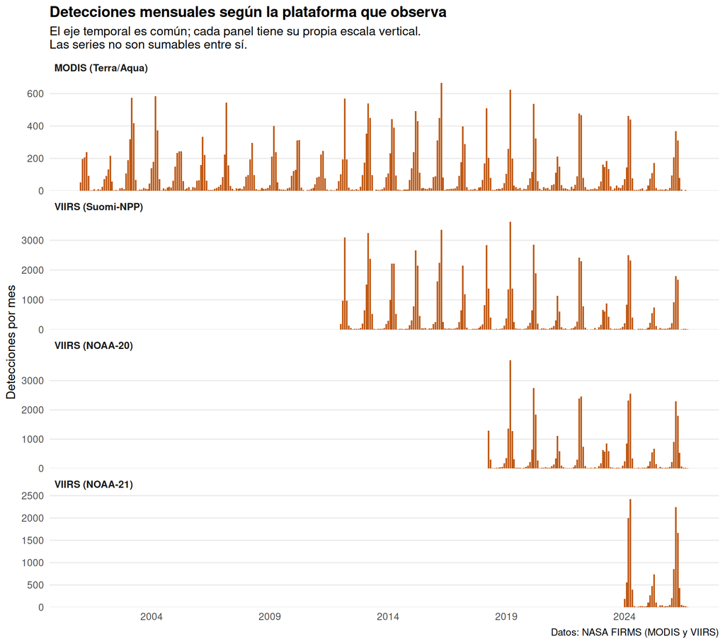

La escalera es evidente en la figura: cada panel arranca cuando su plataforma entró en servicio, y las alturas no son comparables entre paneles. Por eso hay cuatro reportes y no uno.

## Por qué importa tener varias

Mantener cuatro series paralelas no es redundancia. Sirve para tres cosas.

**Continuidad.** Las misiones Terra y Aqua, que llevan MODIS, terminan en 2027. La serie más larga del proyecto —veinticinco años— se corta ahí, y las plataformas VIIRS son su relevo. Tenerlas ya procesadas con la misma metodología permite que el empalme no se improvise.

**Contraste.** Cuando cuatro instrumentos independientes coinciden en un hallazgo, ese hallazgo no es un artefacto de ninguno de ellos. Y cuando difieren, la diferencia misma informa: sobre el mismo incendio, MODIS y VIIRS pueden registrar conteos que difieren en un orden de magnitud, y esa brecha mide el efecto del tamaño del píxel.

**Cobertura reciente.** Las series se sirven del procesamiento estándar y, a continuación, de los datos en tiempo casi real, que llegan hasta hace pocos días. Ese tramo final aparece marcado como provisional en todos los productos: sus detecciones se refinan cuando la NASA las reprocesa. NOAA-21 es un caso aparte: no tiene procesamiento estándar en absoluto, así que **todo** su registro es provisional.

## Lo que coinciden en mostrar

Cada reporte desarrolla sus propios resultados. Tres conclusiones aparecen en los cuatro, y por eso se enuncian aquí como rangos entre plataformas.

**El fuego es un fenómeno de la estación seca.** Entre el **84,9 y 90,7 %** de las detecciones de cada plataforma ocurre de enero a abril, la estación seca del Pacífico. La climatología mensual de cada reporte muestra el mismo perfil con instrumentos y períodos distintos.

**Dónde se concentra.** Las cuatro plataformas coinciden en la misma área de conservación como la de más detecciones: **Tempisque**. Cada reporte desagrega las detecciones y las hectáreas quemadas por área de conservación del SINAC.

**Parte del «pastizal» que arde es humedal estacional.** El mapa global de cobertura clasifica como pastizal buena parte de la vegetación herbácea inundable del país. Cruzando cada detección con el Registro Nacional de Humedales del SINAC, entre el **10,2 y 17,6 %** de las detecciones dominadas por «pastizal» caen dentro de un humedal registrado, según la plataforma. El resultado se sostiene con footprints que van de un kilómetro a 375 metros, lo que descarta que sea un efecto de la superposición gruesa del píxel más grande.

## Un episodio con cifra oficial: Catalina, mayo de 2026

El 28 de mayo de 2026 un rayo encendió el interior del humedal Catalina, en el Parque Nacional Palo Verde (cuenca baja del Tempisque). Delfino.cr reportó, con cifras del Minae-Sinac, que el fuego afectó **cerca de 4 000 hectáreas** ([nota del 3 de junio de 2026](https://delfino.cr/2026/06/incendio-en-parque-nacional-palo-verde-afecto-cerca-de-4000-hectareas)); el combustible principal fue la *Typha*, una planta invasora que arde incluso sobre el agua. Es el único episodio del registro con fecha de ignición, causa y superficie conocidas por una fuente ajena al satélite, y por eso permite algo que ninguna otra parte de estos reportes permite: **auditar los productos contra una medición hecha en tierra**.

La comparación entre plataformas es en sí misma un resultado. Sobre el mismo fuego, los mismos días y el mismo humedal:

- **MODIS** — 11 detecciones en 3 días; FRP máximo 50,3 MW.
- **VIIRS S-NPP** — sin detecciones: su procesamiento estándar tiene una laguna en esas fechas (ver su reporte).
- **VIIRS NOAA-20** — 176 detecciones en 5 días; FRP máximo 68,1 MW.
- **VIIRS NOAA-21** — 126 detecciones en 4 días; FRP máximo 132,8 MW.

La diferencia no está en el fuego sino en el píxel: el de MODIS mide ~1 km de lado y promedia la radiancia sobre una superficie siete veces mayor que el de 375 m de VIIRS, de modo que un frente de llama que ocupa una fracción del píxel puede no elevar su temperatura aparente lo suficiente. **Un incendio de miles de hectáreas se reduce a un puñado de píxeles en la serie más larga**, que es el argumento más concreto a favor de mantener las cuatro plataformas en paralelo.

**Y el área quemada se queda muy corta.** Para mayo y junio de 2026 los productos de área quemada marcan entre 2095 y 3228 hectáreas en la zona del evento, frente a las 4 000 reportadas oficialmente: **entre 1,2 y 1,9 veces menos superficie**.

La razón está en el algoritmo: declara quemado un píxel de 500 m cuando detecta un cambio persistente de reflectancia, y una quema de *Typha* sobre lámina de agua no lo produce —la vegetación emergente desaparece, el agua vuelve a dominar la señal y a las pocas semanas la superficie se parece a lo que era antes—. Las hectáreas de estos reportes **sirven para comparar años entre sí, no para responder cuántas hectáreas se quemaron**. Cada reporte desarrolla el episodio con sus propias cifras.

## Los reportes

- **MODIS (Terra/Aqua)** — 29 520 detecciones, de 01/2001 a 08/2026. Área quemada: MCD64A1.
- **VIIRS (Suomi-NPP)** — 84 095 detecciones, de 01/2012 a 09/2026. Área quemada: VNP64A1.
- **VIIRS (NOAA-20)** — 41 046 detecciones, de 04/2018 a 09/2026. Área quemada: VNP64A1, S-NPP.
- **VIIRS (NOAA-21)** — 13 135 detecciones, de 01/2024 a 09/2026. Área quemada: VNP64A1, S-NPP. Sin procesamiento estándar: datos provisionales.

Cada uno incluye mapa animado, video resumen, mapa interactivo con deslizador temporal, series y climatología, desagregación por área de conservación, análisis de cobertura de la tierra y el contraste con el Registro Nacional de Humedales. MODIS, Suomi-NPP y NOAA-20 llevan además la suite de índices de la temporada de fuego (longitud, concentración, frecuencia, intensidad y días extremos), y un reporte aparte, **la comparación entre plataformas**, las pone lado a lado en los años que observaron a la vez: índices anuales, anomalías estandarizadas y mapas de acuerdo por celda.

## Fuentes de datos

- **NASA FIRMS** — Fire Information for Resource Management System. Detecciones de fuego activo de MODIS (Collection 6.1) y VIIRS (375 m) en sus versiones de procesamiento estándar y en tiempo casi real. https://firms.modaps.eosdis.nasa.gov/.
- **NASA LP DAAC** — productos mensuales de área quemada a 500 m: MCD64A1 v6.1 (MODIS) y VNP64A1 v002 (VIIRS/Suomi-NPP).
- **IGN / SNIT** — Instituto Geográfico Nacional: límite provincial 1:5000 (la unión de las siete provincias es el límite nacional del análisis). https://www.snitcr.go.cr/.
- **SINAC** — Sistema Nacional de Áreas de Conservación de Costa Rica: áreas de conservación y Registro Nacional de Humedales. https://geos1pne.sirefor.go.cr/wfs.
- **ESA WorldCover** — cobertura de la tierra 2021 a 10 m. https://esa-worldcover.org/.

El código de este proyecto está disponible en https://github.com/incendios-forestales/anomalias-termicas-costarica.